# Introduction aux modèles linéaires

# 7 Qualité d’ajustement du modèle

## 7.1 Coefficient de détermination

**NoteDéfinition : Coefficient de détermination**

On appelle le coefficient de détermination $R^2$ la proportion de la variabilité de $Y$ expliquée par le modèle. Cette proportion est donnée par

$$R^2 = \frac{SCM}{SCT}$$

- On a $0\leq R^2\leq 1$. Plus $R^2$ est proche de $1$, meilleur est l’ajustement.
- Si la qualité d’ajustement est mauvais on ne peut pas espérer avoir une bonne prédiction.

## 7.2 Visualisation : Coefficient de détermination

#### 7.2.0.1 Modèle avec pente significative.

$$R^2 = 0.8395522$$

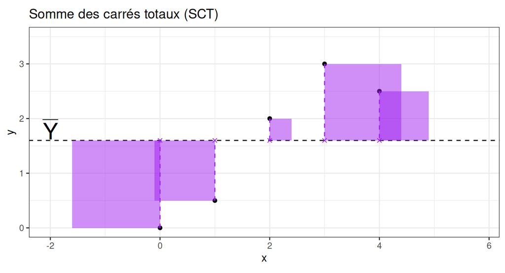

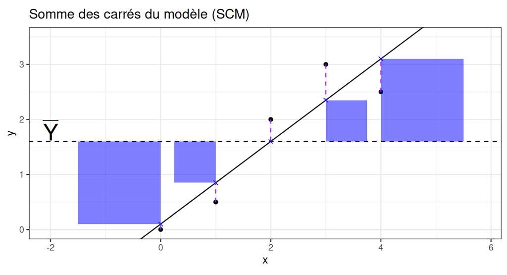

#### 7.2.0.2 Modèle sans pente significative.

$$R^2 = 0.0353026$$

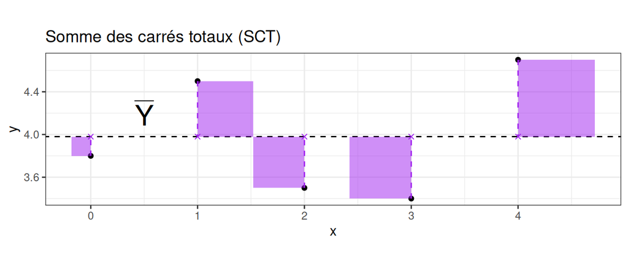

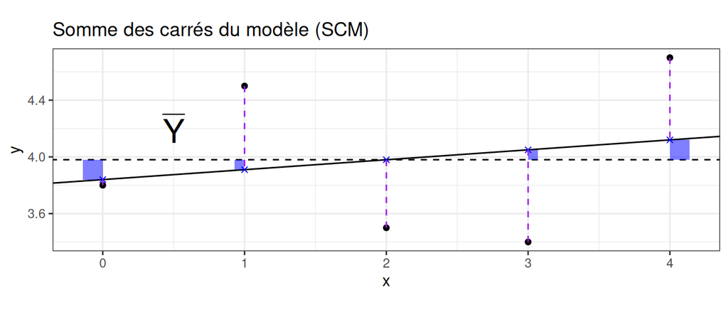

# 8 Prévision: intervalles de confiance et de prédiction

## 8.1 Prévision

- Données $(x_i,y_i)_{i=1,\cdots,n}$ modélisées par
  $$Y_i=\alpha x_i+\beta +E_i,\quad E_i\overset{i.i.d.}\sim{\cal N}(0,\sigma^2)$$
- **Problématique**
  - Etant donnée une valeur $x_0$ de $x$ pour laquelle on n’a pas observé $y_0$, construire une prévision de ce $y_0$ non disponible
  - prévision intuitive par droite des moindres carrées de $y_0$ : $\widehat{y_0}=ax_0+b$
  - Quel sens lui donner ? Quelle qualité ?

## 8.2 Prévision

- ${\widehat y}_0 = ax_0 +b$ est une réalisation de la variable aléatoire $\widehat{Y_0}$ définie par $\widehat{Y_0}=Ax_0+B$
- $\mathbb{E}[\widehat{Y_0}]=\alpha x_0+\beta$ : $\widehat{Y_0}$ est un estimateur sans biais de $\mathbb{E}[Y_0] = \alpha x_0+\beta$
- De plus, si $y_0$ était disponible, on lui associerait une v.a. $Y_0$ définie par
  $$Y_0=\alpha x_0+\beta + E_0,\quad
  E_0\overset{i.i.d}\sim{\cal N}(0,\sigma^2)$$
- $\widehat{y_0}$ est donc à la fois une estimation de $\mathbb{E}[Y_0]$ et une prévision de $y_0$

## 8.3 Deux problématiques

**Warning1 : On ne prend pas en compte la variabilité de $E_0$**

$\widehat{y_0} = a x_0 +b$ est une estimation de $\mathbb{E}[Y_0]$ :

- Construire un intervalle de confiance pour le paramètre $\mathbb{E}[Y_0]$. On s’interesse ici à la partie de la réponse expliquée par le modèle. (Seulement la partie du poids du poisson qui est expliquée par sa longueur)
- En faisant varier $x_0$, construire un intervalle de confiance de la droite de régression $\alpha x+\beta$

**Warning2 : On prend en compte la variabilité de $E_0$**

$\widehat{y_0}$ est une prévision de $y_0$ :

- Construire un intervalle de prédiction pour $Y_0$.

On s’interesse ici à la totalité de la réponse. (On veut un intervalle sur le poids du poisson totale.)

## 8.4 Intervalle de confiance de $\mathbb{E}[Y_0]$

**TipThéorème**

$\widehat{Y_0}=Ax_0+B$ est un estimateur sans biais de $\mathbb{E}[Y_0]=\alpha x_0+ \beta$, de variance
$$\mathbb{V}\left[\widehat{Y_0}\right]=\sigma^2\left(\frac{1}{n}+\frac{(x_0-\bar{x})^2}{\sum_{i=1}^n(x_i-\bar{x})^2}\right).$$

L’estimateur de la variance $\mathbb{V}\left[\widehat{Y_0}\right]$ est donnée par
$$S_0^2=S^2\left(\frac{1}{n}+\frac{(x_0-\bar{x})^2}{\sum_{i=1}^n(x_i-\bar{x})^2}\right)$$

De plus,
$$\frac{\left(\widehat{Y_0}-\mathbb{E}[Y_0]\right)}{S_0}\sim \mathcal{T}(n-2)$$

## 8.5 Intervalle de confiance de $\mathbb{E}[Y_0]$

**TipThéorème**

Intervalle de confiance de $\mathbb{E}[Y_0]$ au niveau de confiance $1-\delta$

$$IC_{1-\delta}(\mathbb{E}[Y_0]) =
\left[\widehat{y_0}-t_{1-\frac{\delta}{2}}\ s_0;\right.
\left.\widehat{y_0}+t_{1-\frac{\delta}{2}}\ s_0\right],$$
où

- $s_0 = \sqrt{s^2\left(\frac{1}{n}+\frac{(x_0-\bar{x})^2}{\sum_{i=1}^n(x_i-\bar{x})^2}\right)}$
- $t_{1-\frac{\delta}{2}}$ est tel que $\mathbb{P}\left(\mid \mathcal{T}(n-2)\mid \leq t_{1-\frac{\delta}{2}}\right)=1-\delta$.

## 8.6 Intervalle de confiance de la droite de régression

**CautionRemarques**

$IC_{1-\delta}(\mathbb{E}[Y_0]) = \left[\widehat{y_0}-t_{1-\frac{\delta}{2}}\ s_0;\right.\left.\widehat{y_0}+t_{1-\frac{\delta}{2}}\ s_0\right],$ avec $s_0 = \sqrt{s^2\left(\frac{1}{n}+\frac{(x_0-\bar{x})^2}{\sum_{i=1}^n(x_i-\bar{x})^2}\right)}$

- En faisant varier $x_0$, les IC définissent deux hyperboles qui sont l’IC de la droite de régression
- Plus on s’éloigne du point moyen $(\bar{x},\bar{y})$, moins l’estimation est précise

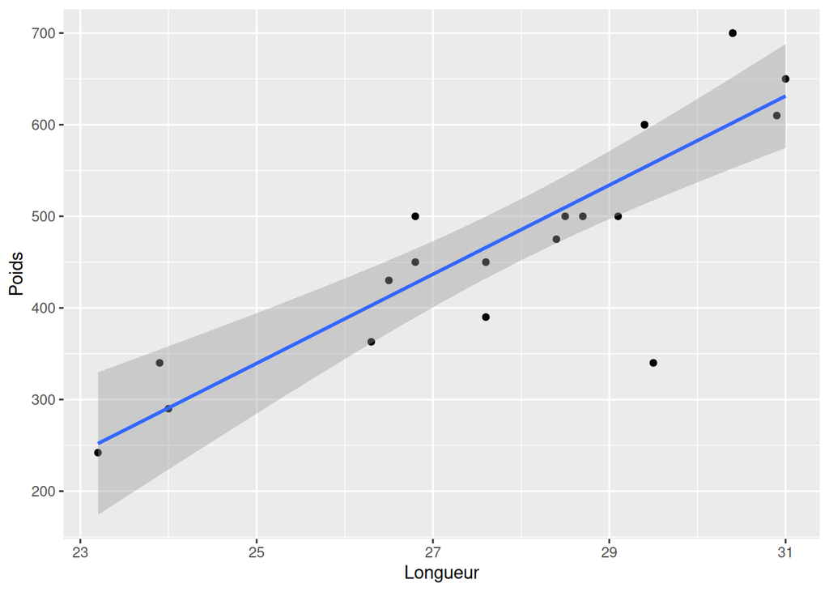

## 8.7 Intervalle de prévision de $Y_0$

On rajoute l’aléa non expliqué par le modèle

**TipThéorème**

$Y_0=\alpha x_0+\beta + E_0$

$$\begin{align}\mathbb{V}(\widehat{Y_0} - Y_0)&= \mathbb{V}[Ax_0+ B] + \mathbb{V}[E_0] \\&= \sigma^2\left( 1 + \frac{1}{n}+\frac{(x_0-\bar{x})^2}{\sum_{i=1}^n(x_i-\bar{x})^2}\right)\end{align}$$
estimée par
$$S_{P_0}^2=S^2\left( 1 + \frac{1}{n}+\frac{(x_0-\bar{x})^2}{\sum_{i=1}^n(x_i-\bar{x})^2}\right)$$
De plus,
$$\frac{(\widehat{Y_0} -Y_0)}{S_{P_0}}\sim\mathcal{T}(n-2)$$

## 8.8 Intervalle de prévision de $Y_0$

**TipThéorème**

$$\frac{(\widehat{Y_0}-Y_0)}{\sqrt{S^2\left(1+\frac{1}{n}+\frac{(x_0-\bar{x})^2}{\sum_{i=1}^n(x_i-\bar{x})^2}\right)}}\sim\mathcal{T}(n-2)$$
**Intervalle de prédiction de** $Y_0$ de niveau $1-\delta$ :

$$IP_{1-\delta}(Y_0)=$$

$$\begin{align}
&\left[\widehat{y_0}-t_{1-\frac{\delta}{2}}\sqrt{s^2\left(1+\frac{1}{n}+\frac{(x_0-\bar{x})^2}{\sum_{i=1}^n(x_i-\bar{x})^2}\right)};\right.\\
&\left.\widehat{y_0}+t_{1-\frac{\delta}{2}}\sqrt{s^2\left(1+\frac{1}{n}+\frac{(x_0-\bar{x})^2}{\sum_{i=1}^n(x_i-\bar{x})^2}\right)}\right]
\end{align}$$

où $t_{1-\frac{\delta}{2}}$ est tel que $\mathbb{P}\left(\mid \mathcal{T}(n-2)\mid \leq t_{1-\frac{\delta}{2}}\right)=1-\delta$

**CautionRemarques**

$$IC_{1-\delta}(\mathbb{E}[Y_0])\subset
IP_{1-\delta}(Y_0)$$

## 8.9 Représentation intervalle de confiance et de prévision

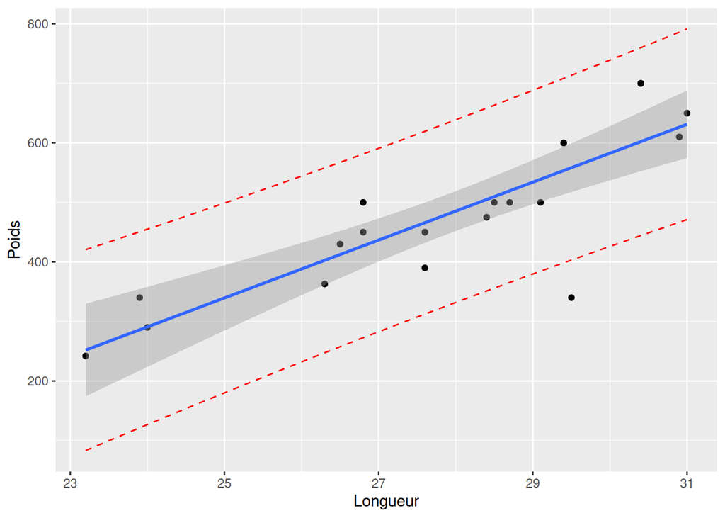

## 8.10 Prévisions avec R

- Prédiction des $\widehat{y}_i = ax_i+b$ (utilisés pour faire le modèle)

```r
y_hat <- fitted(modele_reg_simple)
head(y_hat)
```

```
       1        2        3        4        5        6
251.9271 290.8378 285.9740 402.7059 412.4336 427.0251
```

- Prédiction du poids d’un poisson qui mesurerait 30 cm: pour $x_0=30$

```r
new_data <- data.frame(Longueur = 30)
```

- Prédiction et intervalle de confiance ( de $E[Y_0]$)

```r
predict(modele_reg_simple, new_data,interval="confidence")
```

```
       fit      lwr      upr
1 582.6677 537.0726 628.2628
```

- Prédiction et intervalle de prévision ( de $Y_0$)

```r
predict(modele_reg_simple, new_data, interval = "prediction")
```

```
       fit      lwr      upr
1 582.6677 426.1422 739.1932
```

## 8.11 Ce qu’il faut retenir de ce cours 1/3

**TipLois des estimateurs**

$$\frac{(A-\alpha)}{S_A}\sim \mathcal{T}{(n-2)}$$

$$\frac{(B-\beta)}{S_B}\sim \mathcal{T}{(n-2)}$$

**TipEstimateurs du modèle**

$$\begin{align}
IC_{1-\delta}(\alpha) =& \left[a-t_{1-\frac{\delta}{2}} s_A;a+t_{1-\frac{\delta}{2}} s_A\right]\\
IC_{1-\delta}(\beta)=&\left[b-t_{1-\frac{\delta}{2}} s_B;b+t_{1-\frac{\delta}{2}} s_B\right]\\
\end{align}$$

$s_A = \sqrt{\frac{s^2}{\sum_{i=1}^n(x_i-\bar{x})^2}}$ et $s_B = \sqrt{s^2\left(\frac{1}{n}+\frac{\bar{x}^2}{\sum_{i=1}^n(x_i-\bar{x})^2}\right)}$

**NoteTest de Student de la nullité de la pente de régression**

$$H_0:\alpha=0$$

$$H_1:\alpha\neq 0$$

**NoteTest de Fisher de Comparaison de modèles**

$$H_0\; :\; \text{modèle}\; M_1:Y_i=\beta+E_i$$

$$H_1\; :\; \text{modèle}\; M_2:Y_i=\alpha x_i+\beta+E_i$$

## 8.12 Ce qu’il faut retenir de ce cours 2/3

**NoteDéfinition : SCT**

La variabilité de $Y$ **sans tenir compte du modèle**.

$$\color{purple}{SCT =\displaystyle\sum_{i = 1}^n( Y_i - \bar{Y})^2}$$

**NoteDéfinition : SCM**

Partie de la variabilité de $Y$ **expliquée par le modèle**.

$$\color{blue}{SCM = \displaystyle\sum_{i=1}^n(\widehat{Y_i}-\bar{Y})^2}$$

**NoteDéfinition : SCR**

Partie de la variabilité de $Y$ qui n’est **pas expliquée par le modèle**.

$$\color{red}{SCR = \displaystyle\sum_{i=1}^n(Y_i-\widehat{Y_i})^2=\displaystyle\sum_{i=1}^n E_i ^2}$$

**TipDécomposition de la variance**

$$\color{purple}{SCT} = \color{blue}{SCM} + \color{red}{SCR}$$

**TipTest de Fisher**

$$T_n=\frac{SCM/1}{SCR/(n-2)} \overset{H_0}{\sim} \mathcal{F}(1,n-2)$$

## 8.13 Ce qu’il faut retenir de ce cours 3/3

**NoteCoefficient de détermination**

$$R^2 = \frac{SCM}{SCT}$$

**TipIntervalle de confiance de la droite de régression**

$$IC_{1-\delta}(\mathbb{E}[Y_0])=$$
$$\begin{align}
&\left[\widehat{y_0}-t_{1-\frac{\delta}{2}}\sqrt{s^2\left(\frac{1}{n}+\frac{(x_0-\bar{x})^2}{\sum_{i=1}^n(x_i-\bar{x})^2}\right)};\right.\\
&\left.\widehat{y_0}+t_{1-\frac{\delta}{2}}\sqrt{s^2\left(\frac{1}{n}+\frac{(x_0-\bar{x})^2}{\sum_{i=1}^n(x_i-\bar{x})^2}\right)}\right]
\end{align}$$

**TipIntervalle de prévision**

$$IP_{1-\delta}(Y_0)=$$

$$\begin{align}
&\left[\widehat{y_0}-t_{1-\frac{\delta}{2}}\sqrt{s^2\left(1+\frac{1}{n}+\frac{(x_0-\bar{x})^2}{\sum_{i=1}^n(x_i-\bar{x})^2}\right)};\right.\\
&\left.\widehat{y_0}+t_{1-\frac{\delta}{2}}\sqrt{s^2\left(1+\frac{1}{n}+\frac{(x_0-\bar{x})^2}{\sum_{i=1}^n(x_i-\bar{x})^2}\right)}\right]
\end{align}$$

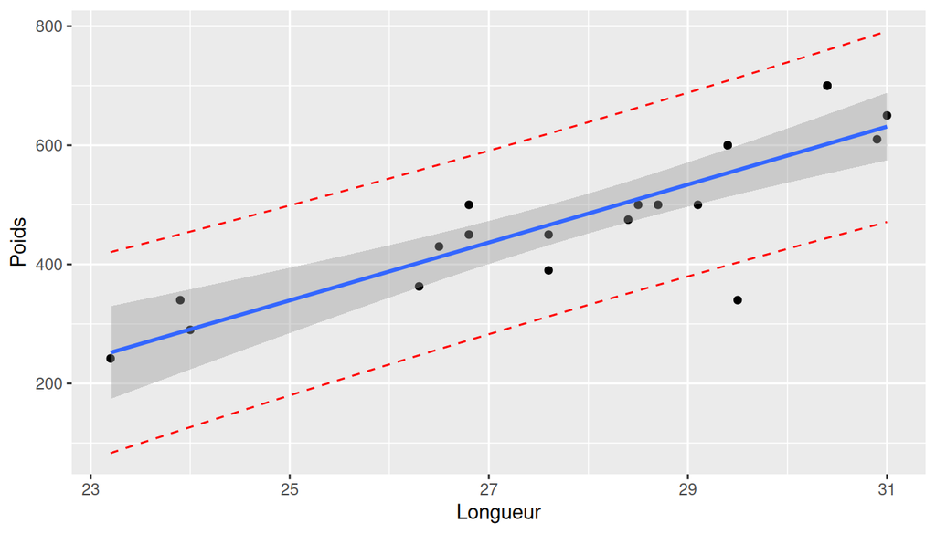